# Simple Linear Regression

Addison van den Hoeven

July 17, 2018

## Overview of Linear Regression

Linear Regression is a very simple approach for performing supervised learning. It is a useful tool for predicting a quantitative response variable $Y$ (also called the dependent variable) using input variables $X_1,...,X_n$ (also called independent variables or regressors) using a simple linear model.

Although it may seem overly simplistic, linear regression is extremely useful both conceptually and practically.

- It is still a widely used statistical learning model
- It serves as a great starting point for newer approaches: many fancy statistical learning approaches can be seen as generalizations or extensions of linear regression

This document is going to dive deeper than is perhaps necesarry in order to provide a detailed understand of the topic and also prepare the reader for more difficult models.

## Intuition behind using models

Suppose that your role is to develope a marketing plan, on the basis of data, for next year that will result in high product sales.

Questions we might ask would be:

- Is there a relationship between advertising budget and sales?
- How strong is the relationship?
- Which media contribute to sales?
- How can we estimate the the effect of each medium on sales?
- How accurately can we predict future sales?
- Is the relationship linear?

Linear Regression can be used to answer all these questions.

## Simple Linear Regression

Simple Linear (SL) Regression is a simple approach for predicting a quantitative response $Y$ on the basis of a single predictor variable $X$. It assumes there is approximately a linear relationship between $X$ and $Y$.

Mathematically, we can write this linear relationship as:

$$Y \approx \beta_0 + \beta_1 X$$
where $\approx$ denotes “approximately modeled as”.

In the above equation, $\beta_0$ and $\beta_1$ are two unknown constants that denote the intercept and slope of the linear model. They are generally referred to as model coefficients or model parameters. Our goal is to find these values.

For example, $X$ may represent visits to the TBS Open Data Portal and $Y$ may represent the number of data downloads from the portal. Below is an example of linear regression used on real data disclosed by TBS on the open data portal:

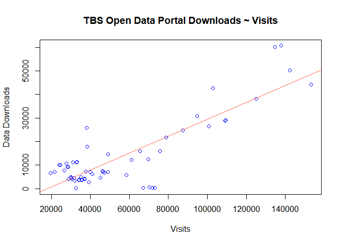

Note: For the sake of focusing on the regression derivation theory, we will assume that the response variables in the example are normally distributed. (Eventually this document will be refactored with better example data)

It is important to remark that:

- In most scientific / engineering phenomena, the relationship between $X$ and $Y$ is not necessarily linear.
- It is also not necessarily deterministic in the sense that a given value $X$ does not always give the same value for $Y$.

As a result, these problems are **probabilitisc** in nature since the relationship is not exact. The concept of regression analysis deals with finding the best relationship between $Y$ and $X$.

Because of this we assume a model where we include an error term:

$$Y = \beta_0 + \beta_1 X + \epsilon$$
where $\epsilon$ is the error term

Given some estimates $\hat{\beta_0}$ and $\hat{\beta_1}$ for the model coefficients, we predict downloads using

$$\hat{y} = \hat{\beta_0} + \hat{\beta_1} x$$
where $\hat{y}$ indicates a prediction of $Y$ on the basis of $X=x$.

- The hat symbol denotes an estimated value.

In practice, $\beta_0$ and $\beta_1$ are unknown. We must use the data to estimate the coefficients/parameters. Now we get into the nitty gritty of regression and actually do a little math to see how we can turn raw data into an approximate linear model.

## Math behind Simple Linear Regression

If you have never derived any statistical or learning model before, simple linear regression is a great place to start. The principles and intuition behind SLR will be invaluable when working towards more complex problems.

Before diving in, just know that it is assumed that you have some familiarity with summation notation, basic calculus, and some sense of statistics. If this is not the case I would still recommend diving in as there is a good chance things will clear up as you read forward and if that is not the case your eyes will have picked up a few things that will trigger a response when you do go to do a little catchup in these domains. Additionaly, moving forward, an understanding of linear algebra and matrix calculus will be very helpful. When working in this space it never hurts to understand more of the math then needed.

Speaking from experience, it may also be helpful to grab some paper and pen/pencil and write down the equations yourself. Solving things on your own is a surefire way to keep things in memory and it may also lead to the creation of your own personalized notes on the subject. Lastly, there is no need to memorize every piece of a derivation. It is there to help you understand and often you do not need to hold the derivatives in memory to fully understand a model’s use case and potential.

### Derivation of Simple Linear Regression: least squares approach

Let $(x_1, y_1), (x_2, y_2),...,(x_n, y_n)$ represent $n$ observation pairs, each of which consists of a measurement of $X$ and $Y$. These value pairs are called the **training data**.

Let $\hat{y_i} = \hat{\beta_0} + \hat{\beta_1} x_i$ be the prediction for $Y$ based on the $i$th value of $X$.

Then $e_i = y_i - \hat{y_i}$ represents the $i$th residual.

We define the **Sum of Squared Errors** (SSE) also called the **Residual Sum of Squares** (RSS) as

$$E(\beta_0, \beta_1) = RSS = e^2_1 + e^2_2 + ... + e^2_n = \sum^n_{i=1} (y_i - \hat{\beta_0} - \hat{\beta_1} x_i)^2$$
where
$$\begin{aligned}
y_i &= \text{actual } y \text{ value in the i'th data pair} \\
\hat{\beta_0} + \hat{\beta_1} x_i &= \text{model prediction of } y_i \\
\epsilon_i &= y_i - \hat{\beta_0} + \hat{\beta_1} x_i \\
\epsilon_i &= \text{the difference between the model prediction } y \text{ and the actual } y
\end{aligned}$$

Our goal is to minimize the $RSS$, effectively minimizing the amount our model is incorrect (since $RSS$ is a function of all our $\epsilon_i$s). To do this we calculate the partial derivatives of the $RSS$ with respect to both $\beta_0$ and $\beta_1$ and set them to zero / solve.

#### Finding the partial derivative of $RSS$ with respect to $\beta_0$

The partial derivative w.r.t. (with respect to) $\beta_0$:

$$\frac{\partial E}{\partial \beta_0} = \frac{\partial}{\partial \beta_0} \Big[ \sum^n_{i=1} (\beta_0 + \beta_1 x_i - y_i)^2 \Big] = 0$$
Utilizing [chain rule](https://www.math.ucdavis.edu/~kouba/CalcOneDIRECTORY/chainruledirectory/ChainRule.html):
$$\Leftrightarrow 2 \sum^n_{i=1}(\beta_0 + \beta_1 x_i - y_i) \frac{\partial}{\partial \beta_0} [\beta_0 + \beta_0 + \beta_1 x_i - y_i] = 0$$
$$\Leftrightarrow \sum^n_{i=1} (\beta_0 + \beta_1 x_i - y_i) (1 + 0 - 0) = \sum^n_{i=1} (\beta_0 + \beta_1 x_i - y_i) = 0$$
Utilizing [Summation Properties](http://tutorial.math.lamar.edu/Classes/CalcI/SummationNotation.aspx):
$$\Leftrightarrow n \beta_0 + \beta_1 \sum^n_{i=1} x_i - \sum^n_{i=1} y_i = 0$$
$$\Leftrightarrow n \beta_0 + \beta_1 \sum^n_{i=1} x_i = \sum^n_{i=1} y_i$$

#### Finding the partial derivative of $RSS$ with respect to $\beta_1$

The partial derivative w.r.t $\beta_1$:

$$\begin{aligned}
\frac{\partial E}{\partial \beta_1} &= \frac{\partial}{\partial \beta_1} \Big[ \sum^n_{i=1} (\beta_0 + \beta_1 x_i - y_i)^2 \Big] = 0 \\
&\Leftrightarrow 2 \sum^n_{i=1}(\beta_0 + \beta_1 x_i - y_i) \frac{\partial}{\partial \beta_1} [\beta_0 + \beta_0 + \beta_1 x_i - y_i] = 0 \\
&\Leftrightarrow \sum^n_{i=1}(\beta_0 + \beta_1 x_i - y_i)x_i = 0 \\
&\Leftrightarrow \beta_0 \sum^n_{i=1} x_i + \beta_1 \sum^n_{i=1} x_i^2 - \sum^n_{i=1} x_i y_i = 0 \\ &\Leftrightarrow \beta_0 \sum^n_{i=1} x_i + \beta_1 \sum^n_{i=1} x_i^2 = \sum^n_{i=1} x_i y_i \end{aligned}$$

#### Finding $\hat{\beta_0}$ and $\hat{\beta_1}$ by minimizing $RSS$

Now that we have found both partial derivatives, we can use them to solve for $\beta_0$ and $\beta_1$ by setting both partial derivatives equal to 0:

$$\begin{aligned}
\frac{\partial E}{\partial \beta_0} &= n \beta_0 + \beta_1 \sum^n_{i=1} x_i - \sum^n_{i=1} y_i = 0\\
\frac{\partial E}{\partial \beta_1} &= \beta_0 \sum^n_{i=1} x_i + \beta_1 \sum^n_{i=1} x_i^2 - \sum^n_{i=1} x_i y_i = 0
\end{aligned}$$
$$n \beta_0 + \beta_1 \sum^n_{i=1} x_i - \sum^n_{i=1} y_i = \beta_0 \sum^n_{i=1} x_i + \beta_1 \sum^n_{i=1} x_i^2 - \sum^n_{i=1} x_i y_i$$
The slope term is:

$$\begin{aligned}
\hat{\beta_1} &= \frac{n\sum^n_{i=1} x_i y_i - (\sum^n_{i=1} x_i)(\sum^n_{i=1} y_i)}{n \sum^n_{i=1} x_i^2 - (\sum^n_{i=1} x_i)^2} \\
\hat{\beta_1}&= \frac{\sum^n_{i=1} (x_i - \bar{x})(y_i - \bar{y})}{\sum^n_{i=1} (x_i - \bar{x})^2} \\
\hat{\beta_1}&= \frac{Cov(x,y)}{Var(x)}
\end{aligned}$$
Where $\bar{y} = \frac{1}{n}\sum^n_{i=1} y_i$ and $\bar{x} = \frac{1}{n}\sum^n_{i=1} x_i$ are the sample means.

The intercept term is:

$$\begin{aligned}
\hat{\beta_0} &= \frac{\sum^n_{i=1} y_i - \hat{\beta_1} \sum^n_{i=1} x_i}{n}
&= \bar{y} - \hat{\beta_1} \bar{x}
\end{aligned}$$

## Least Squares

The above method of performing linear regression is referred to as **Ordinary Least Squares Estimation** (OLSE).

#### Why least squares?

The Least Squares method is designed to minimize the sum of the squares of the residuals ($RSS$) and to provide a fitted line that results in a closeness between the line and the plotted points.

There are many ways of measuring closeness. For example, one may wish to determine $\hat{\beta_0}$ and $\hat{\beta_1}$ using another formula of the combined residuals such as:

$$\sum^n_{i=1} |y_i - \hat{y_i}|$$
or

$$\sum^n_{i=1} |y_i - \hat{y_i}|^{\frac{3}{2}}$$

However, the Least Squares method has the advantage to produce a **differentiable formula** and fit with the known formula of the variance of a random variable. Many other models do not produce a differential formula and must be solved by numerical methods such as gradient ascent/descent (like in logistic regression).

## Properties of least squares estimators

While what we have done above is enough to start predicting values and creating trend lines, it is important to look at the properties of the model and its estimators. This is where a good understanding of fundamental statistical concepts will be very useful. If you are not familiar with terms such as random variables, normal distribution, $t$-distribution, chi-sq disitribution, or variance/indepence, it may be best to do a little reading before hand or along the way.

Below are a few select assumptions and properties of the least squares simple linear regression model:

- In the equation $Y= \beta_0 + \beta_1 X + \epsilon$, the error term $\epsilon$ is assumed to be a normal random variable with $E(\epsilon) = 0$ (recall: $E(\epsilon)$ denotes “expected value of $\epsilon$”) and $Var(\epsilon) = \sigma^2$.
- Thus, $Y$ is also a normal random variable. In general $X$ is not random and can be measured with negligible error.
- The fact that $E(\epsilon) = 0$ implies that at a specific $X$, the $Y$ values are distributed around the true or population regression line $Y= \beta_0 + \beta_1 X$

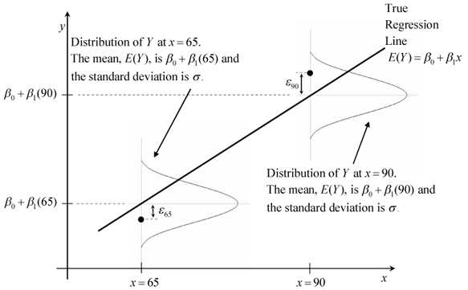

- $Y$ is a random variable for each fixed value of $X$. Observe that:

$$E(Y|X) = \beta_0 + \beta_1 X$$

- The true regression line goes through the means of the response, and the actual observations are on the distribution around the means.

#### The least squares estimators for $\beta_0$ and $\beta_1$

Suppose we make the assumption that $\epsilon_1,...,\epsilon_n$ are independent from run to run in the experiment. This provides a foundation for finding means and variances for the estimators $\beta_0$ and $\beta_1$.

We recall that $\hat{\beta_0}$ and $\hat{\beta_1}$ are only estimates of true parameters $\beta_0$ and $\beta_1$ based on a given sample of $n$ observations. If the experiment is repeated over and over again, each time using the same fixed values of $x$, the resulting estimates of $\beta_0$ and $\beta_1$ will most likely differ from experiment to experiment.

Thus, the estimates of $\beta_0$ and $\beta_1$ may be viewed as values assumed by the random variables $B_0$ and $B_1$ which can be considered as estimators for $\beta_0$ and $\beta_1$. Thus, $\hat{\beta_0}$ and $\hat{\beta_1}$ are specific realizations of the estimators.

Since the values of $X$ remain fixed, the values of $\beta_0$ and $\beta_1$ depend on the variations in the values of $Y$ or, more precisely, on the values of the random variable $Y_1, Y_2, ...,Y_n$. The distributional assumptions imply that $Y_i, i=1,2,...,n$ are also independently distributed, with mean $E(Y_i) = E(Y|x_i) = \beta_0 + \beta_1 x_i$ and equal variances $\sigma^2$; that is:

$$\sigma_{Y|x_i}^2 = \sigma^2 \quad \text{ for } \quad i=1,2,...,n$$

$$\begin{aligned}
B_1 &= \frac{\sum^n_{i=1} (x_i - \bar{x})(Y_i - \bar{Y})}{\sum^n_{i=1} (x_i - \bar{x})^2} = \frac{\sum^n_{i=1} (x_i - \bar{x})Y_i}{\sum^n_{i=1} (x_i - \bar{x})^2} \\
&= \sum^n_{i=1} c_i Y_i
\end{aligned}$$
where
$$c_i = \frac{x_i - \bar{x}}{\sum^n_{i=1} (x_i - \bar{x})^2}, \quad i=1,...,n$$

It follows that $B_1$ is normally distribution with mean
$$\mu_{B_1} = \frac{\sum^n_{i=1} (x_i - \bar{x})(\beta_0 + \beta_1 x_i)}{\sum^n_{i=1} (x_i - \bar{x})^2} = \beta_1$$
Thus, it is an unbiased estimator of $\beta_1$ and its variance is
$$\sigma^2_{B_1} = \frac{\sum^n_{i=1} (x_i - \bar{x})^2 \sigma^2_{Y_i}}{\Big [ \sum^n_{i=1} (x_i - \bar{x})^2 \Big ]^2 } = \frac{\sigma^2}{\sum^n_{i=1} (x_i - \bar{x})^2}$$

The least squares estimator for $\beta_0$ is given by
$$B_0 = \bar{Y} - \bar{x} B_1$$
It follows that $B_0$ is also normally distributed with mean
$$\mu_{B_0} = E(\bar{Y}) - \bar{x} E(B_1) = \beta_0$$
Thus, it is an unbiased estimator of $\beta_0$.

Its variance is

$$\sigma^2_{B_0} = \frac{\sum^n_{i=1} x_i^2}{n \sum^n_{i=1} (x_i -\bar{x})^2} \sigma^2$$

To draw inferences on $\beta_0$ and $\beta_1$, it becomes necessary to arrive at an estimate of the parameter $\sigma^2$ appearing in the two preceding variance formulas for $B_0$ and $B_1$.

The parameter $\sigma^2$, the model error variance, reflects random variation or experimental error variation around the regression line. We define:

$$\begin{aligned}
S_{xx} &= \sum^n_{i=1} (x_i - \bar{x})^2 \\
S_{yy} &= \sum^n_{i=1} (y_i - \bar{y})^2\\
S_{xy} &= \sum^n_{i=1} (x_i - \bar{x})(y_i - \bar{y})
\end{aligned}$$

Now we may write

$$\begin{aligned}
RSS &= S_{yy} - 2 \hat{\beta_1} S_{xx} + \hat{\beta_1}^2 S_{xx}\\
&= S_{yy} - \hat{\beta_1} S_{xy} \quad (\text{since} \quad \hat{\beta_1} = S_{xy}/S_{xx})
\end{aligned}$$

It follows that

$$s^2 = \frac{RSS}{n-2} = \sum^n_{i=1} \frac{(y_i - \hat{y_i})^2}{n-2} = \frac{S_{yy} - \hat{\beta_1} S_{xy}}{n-2}$$
is an unbiased estimator of $\sigma^2$.

The parameter $\sigma^2$ measures the squared deviations between $Y$ values and their mean given by $E(Y/x)$, i.e., squared deviations between $Y$ and $\beta_0 + \beta_1 x$ which is estimated by $\hat{y} = \hat{\beta_0} + \hat{\beta_1} x$.

Thus it would make sense that $\sigma^2$ is best depicted as a squared deviation of the typical observation $y_i$ from the estimated mean $\hat{y_i}$.

The quantity $s^2$ is called a mean-squared error (MSE).

## Inferences about the Regression Coefficients

### Statistics of Linear Regression using Least Squares

Under the normality assumption, we can prove that the random variable

$$\frac{(n-2)S^2}{\sigma^2}$$
where
$$S^2 = \frac{RSS}{n-2}$$
is a chi-squared variable with $n-2$ degrees of freedom and it is independent of the random variable $B_1$.

It follows that the statistic

$$T = \frac{(B_1 - \beta_1)/(\sigma / \sqrt{S_{xx}})}{S/ \sigma} = \frac{B_1 - \beta_1}{S / \sqrt{S_{xx}}}$$
has a $t$-distribution with $n-2$ degrees of freedom.

The statistic $T$ can be used to construct a $100(1 - \alpha) \%$ confidence interval for the coefficient $\beta_1$.

A $100(1- \alpha)\%$ confidence interval for the parameter $\beta_1$ in the regression line

$$E(Y/x) = \beta_0 + \beta_1 x$$
is given by
$$\hat{\beta_1} - t_{\alpha / 2} \frac{s}{\sqrt{S_{xx}}} < \beta_1 < \hat{\beta_1} + t_{\alpha / 2} \frac{s}{\sqrt{S_{xx}}}$$
where $t_{\alpha / 2}$ is a value of the $t$-distribution with $v=n-2$ degrees of freedom leaving an area of $\alpha / 2$ to the right.

Standard errors can also be used to perform hypothesis tests on the coefficients. The most common hypothesis test involves testing the null hypothesis of:
$$H_0: \text{There is no relationship between X and Y}$$
or
$$H_1: \text{There is some relationship between X and Y}$$

Mathematically this corresponds to testing:
$$H_0: \beta_1 = 0$$
versus
$$H_1: \beta_1 \neq 0$$
since if $\beta_1 = 0$ then the model reduces to $Y= \beta_0 + \epsilon$ and $X$ is not associated with $Y$.

To test the null hypothesis, we compute a $t$-statistic, given by
$$t=\frac{\hat{\beta_1} - 0}{SE(\hat{\beta_1})} = \frac{\hat{\beta_1} - 0}{s/\sqrt{S_{xx}}}$$
This has a distribution with $n-2$ degrees of freedom. Using software it is easy to compute the probability of observing any value equal to $t$ or larger (In your stats classes you will often use a table containing probability values coresponding to specific test-statistic values). This value is called the $p$ value. Roughly speaking we can interpret the $p$-value as follows:

- Small $p$-value $\Rightarrow$ it is unlikely to observe such a substancial association betweeb the predictor and the response due to chance, in the absence of any real association between the predictor and the response.

Confidence intervals and hypothesis testing on the coefficient $\beta_0$ may be established from the fact that $B_0$ is also normally distributed.

It is not difficult to show that
$$T= \frac{B_0 - \beta_0}{S \sqrt{\sum^n_{i=1} x_i^2 /(nS_{xx})}}$$
has a $t$-distribution with $n-2$ degrees of freedom.

We can now construct a $100(1-\alpha)\%$ confidence interval for the coefficient $\beta_0$.

### Quality of Fit

To assess the quality of fit, i.e., how well the simple linear regression model fits the data, we use the Coefficient of Determination, also known as $R$-squared ($R^2$).

We can defined the coefficient of determination as the proportion of the variation in the target variable $y$ explained by the linear regression. It is interpreted as the proportion of the variance in the dependent variable that is predictable from the independent variable.

Lets define the following quantities:

- Total Sum of Squares: $TSS=\sum^n_{i=1} (y_i - \bar{y})^2$
- Explained Sum of Squares: $ESS = \sum^n_{i=1} (\hat{y_i} - \bar{y})^2$

So we see that $TSS$ is essentially a measure of the total variation in $y$ explained by both the regression model and the residual $\epsilon$. Note that $\bar{\hat{y}} = \bar{y}$:

$$\begin{aligned}
\bar{\hat{y}} &= \frac{1}{n} \sum^n_{i=1} \hat{y_i} = \frac{1}{n} \sum^n_{i=1} \hat{\beta_0} + \hat{\beta_1} x_i\\
&= \hat{\beta_0} + \hat{\beta_1}\bar{x} = \bar{y}- \hat{\beta_1} \bar{x} + \hat{\beta_1} \bar{x}\\
&= \bar{y}
\end{aligned}$$

It follows that
$$ESS = \sum^n_{i=1} (\hat{y_i} - \bar{y})^2 = \sum^n_{i=1} (\hat{y_i} - \bar{\hat{y}})^2$$
is the variation in the predicted data.

In other words, it measures the variation explained by the fitted model.

Now, we recall that
$$RSS = \sum^n_{i=1} (y_i - \hat{y_i})^2$$
which is the variation due to error, and usually called the unexplained variation.

The following equality, stating that the total sum of squares equals the residual sum of squares plus the explained sum of squares, is generally true in simple linear regression:

$$\begin{aligned}
\sum^n_{i=1} (y_i - \bar{y})^2 &= \sum^n_{i=1} (y_i - \hat{y_i})^2 + \sum^n_{i=1} (\hat{y_i} - \bar{y})^2 \\
TSS &= RSS + ESS
\end{aligned}$$

The coefficient of determination $R^2$ is defined as
$$R^2 = \frac{ESS}{TSS} = 1 - \frac{RSS}{TSS}$$

$0 \leq R^2 \leq 1$ is the proportion of total variation in the target variable explained by the regression model.

If $RSS = 0 $, all residuals are zero $\Rightarrow$ the fit is perfect. Hence, in this case all the variation is explained and $R^2 = 1$.

On the other hand, for a poor fitting model, $RSS$ is large (close to $TSS$) and $ESS$ is small. And consequently, $R^2$ will be small (close to 0).

The problem with the coefficient of determination $R^2$ is that in a given application we don’t necessarily know what acceptable values of $R^2$ we may use to assess the model.

- Adding additional terms to the model (e.g. an additional regressor) decreases $RSS$ and thus increases $R^2$.
- This implies that $R^2$ can be made artificially high by an unwise practice of overfitting (i.e. the inclusion of too many model terms).

## Prediction

One of the main objectives of building a linear regression model is to predict response values at one or more values of the independent variable.

The equation
$$\hat{y} = \hat{\beta_0} + \hat{\beta_1} x$$
may be used to predict or estimate the mean response $\mu_{Y|x_0}$ at $x=x_0$, where $x_0$ is not necessarily one of the pre-chosen values in a the training data. It may also be used to predict a single value $y_0$ of the variable $Y_0$, when $x=x_0$.

Suppose that the experimenter wishes to construct a confidence interval for $\mu_{Y|x_0}$. We may use the estimator $\hat{Y_0} = B_0 + B_1 x_0$ to estimate
$$\mu_{Y| x_0} = \beta_0 + \beta_1 x_0$$
It can be shown that the sampling distribution of $\hat{Y_0}$ is normal with mean
$$E(\hat{Y_0}) = \mu_{Y|x_0}$$
Hence, it is an unbiased estimator of $\mu_{Y|x_0}$.

The variance of $\hat{Y_0}$ is given by
$$\begin{aligned}
\sigma^2_{\hat{Y_0}} &= \sigma_{B_0 + B_1 x_0}^2 = \sigma^2_{\bar{Y} + B_1 (x_0 - \bar{x})} \\
&= \sigma^2 \Big [ \frac{1}{n} + \frac{(x_0 - \bar{x})^2}{S_{xx}} \Big]
\end{aligned}$$
Note that in order to prove the above equation one needs to prove that
$$Cov(\bar{Y}, B_1) = 0$$

Thus, a $100(1-\alpha)\%$ confidence on the mean response $\mu_{Y|x_0}$ can now be constructed from the statistic
$$T = \frac{\hat{Y_0} - \mu_{Y|x_0}}{S \sqrt{[\frac{1}{n} + \frac{(x_0 - \bar{x})^2}{S_{xx}}]}}$$
which has a $t$-distribution with $n-2$ degrees of freedom.

Thus a $100(1-\alpha)\%$ confidence interval for a single predicted value $y_0$ can be constructed from the statistic
$$T = \frac{\hat{Y_0} - Y_0}{S \sqrt{[1 + \frac{1}{n} + \frac{(x_0 - \bar{x})^2}{S_{xx}}]}}$$
which has a $t$-distribution with $n-2$ degrees of freedom.

## Summary of the theory behind Simple Linear Regression

Before reviewing all the elements covered, observe the example of SLR performed in R using the default library below:

```r
df <- read.csv("TBSOpenDataVisits.csv", header = TRUE)

# Recall: Given a function name x, typing help(x) into the console (or in a script) will
# open an html file inside RStudio that provides you with useful info regarding that function.
#
# Example: help(lm)
fit <- lm(downloads ~ visits, data=df) # lm stands for linear model
print(fit)
```

```
##
## Call:
## lm(formula = downloads ~ visits, data = df)
##
## Coefficients:
## (Intercept)       visits
##  -6478.5542       0.3585
```

In this case the $lm()$ function calculated:

$$\begin{aligned}
\hat{\beta_0} &= -6478.5542\\
\hat{\beta_1} &= 0.3585
\end{aligned}$$
Giving us the model:

$$\begin{aligned}
\hat{y} = \hat{\beta_0} + \hat{\beta_1} x
\end{aligned}$$
where $\hat{y}$ is the predicted number of downloads for any $x$ number of visits to the TBS open data portal.

At this point you might be wondering “this seems awfully simple, why is this document so long?” and for the most part you are correct to think this. There are many other much shorter ways to get to the idea of using a linear model to predict values and interpret data. Getting a working model is the easy part… Evaluating and being able to interpret every piece of a model is a much more complicated task. 95% of the content above was written to hopefully cover most of the major components involved in a complete analysis of a linear regression model.

The model provided by the $lm()$ function can be inputed into the $summary()$ function to give us more details about the coefficients and the quality of fit:

```r
summary(fit)
```

```
##
## Call:
## lm(formula = downloads ~ visits, data = df)
##
## Residuals:
##      Min       1Q   Median       3Q      Max
## -19353.1  -3513.4   -921.4   5603.5  18585.3
##
## Coefficients:
##               Estimate Std. Error t value Pr(>|t|)
## (Intercept) -6.479e+03  1.993e+03   -3.25  0.00195 **
## visits       3.585e-01  3.022e-02   11.86  < 2e-16 ***
## ---
## Signif. codes:  0 '***' 0.001 '**' 0.01 '*' 0.05 '.' 0.1 ' ' 1
##
## Residual standard error: 7887 on 56 degrees of freedom
## Multiple R-squared:  0.7153, Adjusted R-squared:  0.7102
## F-statistic: 140.7 on 1 and 56 DF,  p-value: < 2.2e-16
```

If we were to have simply covered how to calculate $\beta_0$ and $\beta_1$ you can see that much of the information about our model given by the summary equation would be quite confusing. Note that some of the information such as $R^2_{adj}$ is only relevant when performing Multiple Linear Regression and can be ignored for now as we only cover Simple Linear Regression.

#### Major components of the output

We covered several different aspects of linear regression so far. Now we can begin to put them all together to see how we can properly evaluate a simple linear model.

The major components are:

- The coefficient values ($\beta_0$ and $\beta_1$)
- The standard error and $t$-values of the coefficients
- The $p$-values of the model
- The Coefficient of Determination $R^2$ value of the model

#### Coefficient values

Perhaps the most important piece of the output, the coefficient values define the relationship between our dependent and independent variables. These values however, must be interpreted in tandem with the rest of the information outputed from our model in order to provide any significant insights.

#### Standard error and the $t$-values

As we covered earlier, we can compute

$$t=\frac{\hat{\beta_1} - 0}{SE(\hat{\beta_1})} = \frac{\hat{\beta_1} - 0}{s/\sqrt{S_{xx}}}$$

The $t$-value calculated allows for hypothesis testing at different levels of significance. If $|t|$ is sufficiently large, we reject the null hypothesis $H_0:\beta_1 = 0$ and accept the alternate $H_1:\beta_1 \neq 0$. This allows us to draw insights from individual relationships in our model. When moving onto Multiple Linear Regression, concepts like this one allow us to really understand the relationships between variables. Often times we can have a meaningful $R^2$ with many insignificant variables. It is vital, in situations like these, to be able to read the output of your models fluently.

#### $R^2$

We covered the Coefficient of Determination $R^2$ when talkign about the Quality of Fit of a model. Recall that $R^2$ tells us the proportion of variation in the dependent variable that is explained by the model.

$$\begin{aligned}
\sum^n_{i=1} (y_i - \bar{y})^2 &= \sum^n_{i=1} (y_i - \hat{y_i})^2 + \sum^n_{i=1} (\hat{y_i} - \bar{y})^2 \\
TSS &= RSS + ESS \\
\\
R^2 &= \frac{ESS}{TSS} = 1 - \frac{RSS}{TSS}
\end{aligned}$$

While a model with a low $R^2$ does not explain variation in a dataset well, we don’t necessarily discard the model based on solely this. Its a much better practice to look at the predicition accuracy of the model on a test-dataset, or validation set, before deciding on the efficacy of a model.

## Examples

### No library done out in R code

First off, I will load up a csv file with data.

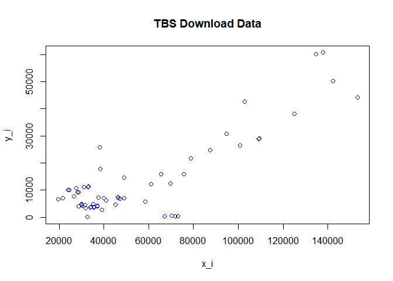

```r
df <- read.csv("TBSOpenDataVisits.csv", header = TRUE)

y_i <- df$downloads
x_i <- df$visits

plot(x = x_i,
     y = y_i,
     main = "TBS Download Data",
     col="blue")
```

#### Finding the coefficient values

Recall the formula for $\hat{\beta_1}$:

$$\begin{aligned}
\hat{\beta_1}&= \frac{\sum^n_{i=1} (x_i - \bar{x})(y_i - \bar{y})}{\sum^n_{i=1} (x_i - \bar{x})^2} \\
\hat{\beta_1}&= \frac{Cov(x,y)}{Var(x)}
\end{aligned}$$

```r
# find beta1

beta1 <- cov(x_i,y_i)/var(x_i)
print(beta1)
```

```
## [1] 0.3585295
```

Recall the formula for $\hat{\beta_0}$:

$$\hat{\beta_0} = \frac{\sum^n_{i=1} y_i - \hat{\beta_1} \sum^n_{i=1} x_i}{n}
= \bar{y} - \hat{\beta_1} \bar{x}$$

```r
# find beta0

beta0 <- mean(y_i) - beta1 * mean(x_i)
print(beta0)
```

```
## [1] -6478.554
```

We can use these values to predict $y_i$ and find $\hat{y_i}$:

```r
# find y_i_predicted

y_i_predicted <- c()
i <- 1
for (x in x_i) {
  y_i_predicted[i] <- beta0 + beta1 * x
  i <- i + 1
}
```

#### Finding the properties of the coefficients and the model

Recall the formula for $R^2$:

$$\begin{aligned}
R^2 &= \frac{ESS}{TSS} \\
TSS &= \sum^n_{i=1} (y_i - \bar{y})^2\\
ESS &= \sum^n_{i=1} (\hat{y_i} - \bar{y})^2
\end{aligned}$$

```r
# find R^2

# initializing variables for TSS and ESS
TSS <- 0
ESS <- 0
y_bar <- mean(y_i)

for (i in 1: length(y_i)) {
  ESS <- ESS + (y_i_predicted[i] - y_bar)^2
  TSS <- TSS + (y_i[i] - y_bar)^2
}

R_squared <- ESS/TSS
print(R_squared)
```

```
## [1] 0.7153186
```